# Twitter Disaster Classification Analysis

## Binary Classification of Disaster-Related Tweets

**Objective:** Develop a machine learning model to classify tweets as either disaster-related or non-disaster content. This can be tricky, as some words normally disaster-related can be used figuratively in otherwise unrelated sentences.

This problem has important applications, as disaster-relief organisations can use the analysed tweets for early-detection of disasters. News agencies could also get an early lead as well as an insight to the reactions of the people.

This analysis utilizes data from the [NLP with Disaster Tweets competition](https://www.kaggle.com/competitions/nlp-getting-started).

**Dataset Characteristics:**

- **id**: Unique tweet identifier
- **text**: Tweet content
- **location**: Geographic origin (optional)
- **keyword**: Significant term from tweet (optional)
- **target**: Binary classification label (train set only)

**Composition:**

**Import required libraries**

```python
import os
import pandas as pd
import numpy as np
import seaborn as sns
from matplotlib import pyplot as plt
from sklearn.compose import ColumnTransformer
from sklearn.ensemble import RandomForestClassifier
from sklearn.metrics import accuracy_score, f1_score, precision_score, recall_score, confusion_matrix, ConfusionMatrixDisplay
from sklearn.model_selection import train_test_split
from sklearn.preprocessing import OrdinalEncoder
from tqdm import tqdm
import re
import tensorflow as tf
from tensorflow.keras import Sequential, layers, Input, Model
from tensorflow.keras.models import load_model
from tensorflow.keras.callbacks import EarlyStopping, ModelCheckpoint, CSVLogger
from tensorflow.keras.optimizers import Nadam
from tensorflow.keras.preprocessing.text import Tokenizer
from tensorflow.keras.preprocessing.sequence import pad_sequences
from tensorflow.keras.utils import custom_object_scope
```

```
2025-09-17 10:47:19.818964: I tensorflow/core/platform/cpu_feature_guard.cc:210] This TensorFlow binary is optimized to use available CPU instructions in performance-critical operations.
To enable the following instructions: AVX2 FMA, in other operations, rebuild TensorFlow with the appropriate compiler flags.
```

**Attack strategy:**

1. Perform comprehensive data exploration
2. Implement text preprocessing pipeline
3. Utilize pretrained word embeddings
4. Develop and compare multiple model architectures
5. Tune the hyperparameters of both RNN models
6. Evaluate performance using F1-score and generate predictions

**Modeling Strategy:**

- Baseline model using metadata features
- RNN architectures with LSTM/GRU cells
- Model selection based on F1-score optimization

## Initial Data Inspection

```python
if 'KAGGLE_URL_BASE' in os.environ:
    df_train = pd.read_csv("/kaggle/input/nlp-getting-started/train.csv")
    df_test = pd.read_csv("/kaggle/input/nlp-getting-started/test.csv")
else:
    DATA_DIR = "data"
    df_train = pd.read_csv(os.path.join(DATA_DIR, "train.csv"))
    df_test = pd.read_csv(os.path.join(DATA_DIR, "test.csv"))
```

```python
print('Training dataset overview:')
display(df_train.info())
df_train.head()
```

```
Training dataset overview:
<class 'pandas.core.frame.DataFrame'>
RangeIndex: 7613 entries, 0 to 7612
Data columns (total 5 columns):
 #   Column    Non-Null Count  Dtype
---  ------    --------------  -----
 0   id        7613 non-null   int64
 1   keyword   7552 non-null   object
 2   location  5080 non-null   object
 3   text      7613 non-null   object
 4   target    7613 non-null   int64
dtypes: int64(2), object(3)
memory usage: 297.5+ KB
```

```
None
```

|  | id | keyword | location | text | target |
| --- | --- | --- | --- | --- | --- |
| 0 | 1 | NaN | NaN | Our Deeds are the Reason of this #earthquake M... | 1 |
| 1 | 4 | NaN | NaN | Forest fire near La Ronge Sask. Canada | 1 |
| 2 | 5 | NaN | NaN | All residents asked to 'shelter in place' are ... | 1 |
| 3 | 6 | NaN | NaN | 13,000 people receive #wildfires evacuation or... | 1 |
| 4 | 7 | NaN | NaN | Just got sent this photo from Ruby #Alaska as ... | 1 |

```python
print('Test dataset overview:')
display(df_test.info())
df_test.head()
```

```
Test dataset overview:
<class 'pandas.core.frame.DataFrame'>
RangeIndex: 3263 entries, 0 to 3262
Data columns (total 4 columns):
 #   Column    Non-Null Count  Dtype
---  ------    --------------  -----
 0   id        3263 non-null   int64
 1   keyword   3237 non-null   object
 2   location  2158 non-null   object
 3   text      3263 non-null   object
dtypes: int64(1), object(3)
memory usage: 102.1+ KB
```

```
None
```

|  | id | keyword | location | text |
| --- | --- | --- | --- | --- |
| 0 | 0 | NaN | NaN | Just happened a terrible car crash |
| 1 | 2 | NaN | NaN | Heard about #earthquake is different cities, s... |
| 2 | 3 | NaN | NaN | there is a forest fire at spot pond, geese are... |
| 3 | 9 | NaN | NaN | Apocalypse lighting. #Spokane #wildfires |
| 4 | 11 | NaN | NaN | Typhoon Soudelor kills 28 in China and Taiwan |

```python
print('Sample tweet instances:\n')
for row in np.random.choice(len(df_train), size=5, replace=False):
    print('(id=%s, label=%s), text: %s' % (df_train.loc[row,'id'], df_train.loc[row,'target'], df_train.loc[row,'text']))
```

```
Sample tweet instances:

(id=10605, label=0), text: Have you ever seen the President
who killed your wounded child?
Or the man that crashed your sister's plane
claimin' he was sent of God?
(id=7603, label=0), text: @J3Lyon I'm going to put the FFVII ones out at the weekend so I think Pandemonium! (Don't forget the exclamation mark) would be midweek.
(id=6844, label=0), text: matako_milk: Breaking news! Unconfirmed! I just heard a loud bang nearby. in what appears to be a blast of wind from my neighbour's ass.
(id=680, label=1), text: Suspect in latest US theatre attack had psychological issues http://t.co/OnPnBx0ZEx http://t.co/uM5IcN5Et2
(id=7301, label=1), text: Salem 2 nuclear reactor shut down over electrical circuit failure on pump: The Salem 2 nuclear reactor had bee... http://t.co/5hkGXzJLmX
```

```
Class distribution:
0    4342
1    3271
```

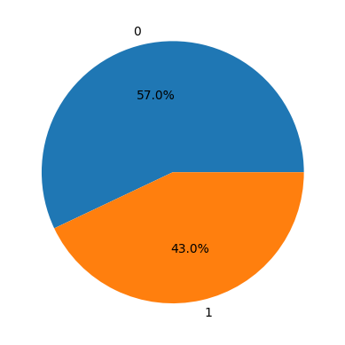

```python
# Class distribution
print('Class distribution:')
df_train.target.value_counts().plot.pie(autopct='%1.1f%%', ylabel='')
print(df_train.target.value_counts().to_string(header=False))
```

```
Average training text length: 101
		when label=1: 108
		when label=0: 95
```

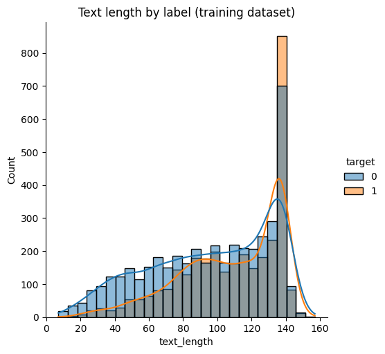

```python
# Text length (training)
df_train['text_length'] = df_train['text'].apply(len)
sns.displot(data=df_train, x='text_length', hue='target', kde=True, legend=True).set(title='Text length by label (training dataset)')

print('Average training text length: %d' % df_train['text_length'].mean())
print('\t\twhen label=1: %d' % df_train[df_train['target'] == 1]['text_length'].mean())
print('\t\twhen label=0: %d' % df_train[df_train['target'] == 0]['text_length'].mean())
```

```
Average training text length: 102
```

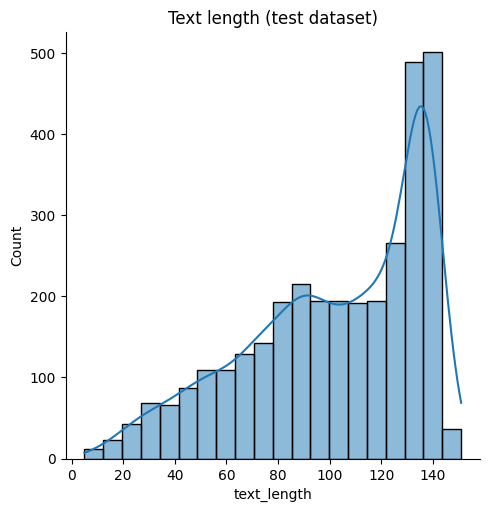

```python
# Text length (test)
df_test['text_length'] = df_test['text'].apply(len)
sns.displot(data=df_test, x='text_length', kde=True, legend=True).set(title='Text length (test dataset)')

print('Average training text length: %d' % df_test['text_length'].mean())
```

### Observations

It seems that negatives are slightly more that the positives in this dataset, but not enough to be a source of concern. As for the text length, it seems that the training and test datasets are close, having a similar pattern of a strong spike near Twitter's word limit. It seems though that there is a difference depending on the label: positives are more skewed towards the word limit.

## Data cleaning

As seen above, the columns `location` and `keyword` are sometimes blank. To fix this, the empty cells will be filled with the value `unkown`. The text also has many characters/objects which need to be cleaned/generalized, such as URLs, mentions, and emojis. This is required to use GloVe later on.

Later, the text will need to be tokenized for processing be the ML algorithms. The GloVe models will be used to vectorize the tweets based on their trained models.

```python
# Fill empty cells
for df in df_train, df_test:
    df['location'].fillna('unknown', inplace=True)
    df['keyword'].fillna('unknown', inplace=True)
```

### Text Cleaning Process

```python
def clean_text(text):
    """Apply regex transformations to normalize tweet text following GloVe preprocessing"""

    def process_hashtag(hashtag):
        """Process hashtag content according to GloVe specifications"""
        hashtag_body = hashtag.group(1)
        if hashtag_body.upper() == hashtag_body:
            return "<HASHTAG> " + hashtag_body + " <ALLCAPS>"
        else:
            # Split on uppercase letters and numbers followed by uppercase
            split_pattern = r'(?=[A-Z])|(?<=[0-9])(?=[A-Z])|(?<=[A-Z])(?=[0-9])'
            parts = re.split(split_pattern, hashtag_body)
            parts = [p for p in parts if p]  # Remove empty strings
            return "<HASHTAG> " + ' '.join(parts)

    # Different regex parts for smiley faces
    eyes = r"[8:=;]"
    nose = r"['`\-]?"

    transformations = [
        # URLs first
        (r"https?://\S+\b|www\.(\w+\.)+\S*", "<URL>"),
        # Force splitting words appended with slashes
        (r"/", " / "),
        # User mentions
        (r"@\w+", "<USER>"),
        # Smileys and emoticons
        (rf"{eyes}{nose}[)d]+|[)d]+{nose}{eyes}", "<SMILE>", re.IGNORECASE),
        (rf"{eyes}{nose}p+", "<LOLFACE>", re.IGNORECASE),
        (rf"{eyes}{nose}\(+|\)+{nose}{eyes}", "<SADFACE>"),
        (rf"{eyes}{nose}[\/|l*]", "<NEUTRALFACE>"),
        # Hearts
        (r"<3", "<HEART>"),
        # Numbers
        (r"[-+]?[.\d]*[\d]+[:,.\d]*", "<NUMBER>"),
        # Hashtags
        (r"#(\S+)", process_hashtag),
        # Punctuation repetitions
        (r"([!?.]){2,}", r"\1 <REPEAT>"),
        # Elongated words
        (r"\b(\S*?)(.)\2{2,}\b", r"\1\2 <ELONG>"),
        # All caps words (but not tags that already start with <)
        (r"(?<!\<)\b([A-Z0-9()<>'`\-]{2,})\b", lambda m: m.group(1).lower() + " <ALLCAPS>")
    ]

    for transformation in transformations:
        if len(transformation) == 3:
            pattern, replacement, flags = transformation
            text = re.sub(pattern, replacement, text, flags=flags)
        else:
            pattern, replacement = transformation
            text = re.sub(pattern, replacement, text)

    return text
```

```python
df_train["clean_text"] = df_train["text"].apply(clean_text)
df_test["clean_text"] = df_test["text"].apply(clean_text)

# Show sample of processed text
print("Sample processed tweets:")
for idx in np.random.choice(len(df_train), 3, replace=False):
    print("Original:", df_train.loc[idx, 'text'])
    print("Cleaned :", df_train.loc[idx, 'clean_text'])
    print("-" * 80)
```

```
Sample processed tweets:
Original: Coastal German Shepherd Rescue OC shared a link: 'Ecstatic Rescued Racco... http://t.co/t8Q6DzVgwX #animalrescue
Cleaned : Coastal German Shepherd Rescue oc <ALLCAPS> shared a link: 'Ecstatic Rescued Racco. <REPEAT> <URL> <HASHTAG> animalrescue
--------------------------------------------------------------------------------
Original: Long Road To Ruin - Foo Fighters
Cleaned : Long Road To Ruin - Foo Fighters
--------------------------------------------------------------------------------
Original: @NBCNews Yea bombing #pearlharbor not so good of an idea!
Cleaned : <USER> Yea bombing <HASHTAG> pearlharbor not so good of an idea!
--------------------------------------------------------------------------------
```

## Word Tokenization

```python
tokenizer = Tokenizer(num_words=None, filters='\t\n', lower=True, split=' ')
training_texts = df_train['clean_text'].to_list()
training_texts.append('<blank>')

tokenizer.fit_on_texts(training_texts)
idx_word = tokenizer.index_word
word_idx = {word:idx for idx, word in idx_word.items()}
num_words = len(idx_word) + 1
```

```python
for df in df_train, df_test:
    df['sequences'] = tokenizer.texts_to_sequences(df['clean_text'])
    df['seq_len'] = df['sequences'].apply(len)

blank_id = word_idx['<blank>']
num_words += 1
```

## Load GloVe Embeddings from Text File

GloVe (Global Vectors for Word Representation) serves as the semantic foundation for this NLP project.

The use of GloVe is an example of Transfer learning which we learned about in the last module.

GloVe provides 100-dimensional dense vector representations pre-trained on 27 billion Twitter tokens, capturing linguistic patterns and word relationships specific to social media language. This brings external linguistic knowledge into the model, reducing reliance on our limited training data.

As the limited data in our dataset would add little benefit to the model, the implementation is simplified by applying it as a fixed feature extractor (the pretrained weights are loaded and kept static during training).

The cleaning pipeline applied above aligns with GloVe's training conventions.

This has the benefit of better performace with limited data and faster convergence of the model.

```python
def load_glove_embeddings(glove_file_path):
    """Load GloVe embeddings from text file format"""
    embeddings = {}
    print("Loading GloVe embeddings from %s..." % glove_file_path)

    with open(glove_file_path, 'r', encoding='utf-8') as f:
        for line in tqdm(f, desc="Processing GloVe vectors"):
            values = line.split()
            if len(values) < 2:  # Skip empty lines
                continue
            word = values[0]
            vector = np.asarray(values[1:], dtype='float32')
            embeddings[word] = vector

    print("Loaded %d word vectors" % len(embeddings))
    return embeddings
```

```python
# Load GloVe embeddings
if 'KAGGLE_URL_BASE' in os.environ:
    glove_file_path = "/kaggle/input/glovetwitter27b100dtxt/glove.twitter.27B.100d.txt"
else:
    glove_file_path = os.path.join(DATA_DIR, "glove.twitter.27B.100d.txt")
embeddings = load_glove_embeddings(glove_file_path)
embed_dim = len(next(iter(embeddings.values())))

print("Embedding dimension:", embed_dim)
```

```
Loading GloVe embeddings from data/glove.twitter.27B.100d.txt...
```

```
Processing GloVe vectors: 1193514it [00:22, 53595.23it/s]
```

```
Loaded 1193514 word vectors
Embedding dimension: 100
```

```python
# Create embedding matrix with proper handling of special tokens
embedding_matrix = np.zeros((num_words, embed_dim))

for word, idx in word_idx.items():
    # GloVe embeddings use lowercase versions of special tokens
    glove_word = word.lower()

    if glove_word in embeddings:
        embedding_matrix[idx, :] = embeddings[glove_word]
    elif word == '<blank>':
        # Use a zero vector for padding
        embedding_matrix[idx, :] = np.zeros(embed_dim)
    else:
        # For out-of-vocabulary words, use a random initialization
        embedding_matrix[idx, :] = np.random.normal(0, 0.1, embed_dim)
```

## Data Partitioning

```python
df_train_sub, df_cv_sub = train_test_split(df_train, test_size=.2, stratify=df_train['target'])
y_train = df_train_sub['target']
y_cv = df_cv_sub['target']
```

# Model Development Optimization

```python
# First write some functions to handle metrics
def calc_model_metrics(y_true, y_pred):
    return {
        'accuracy': accuracy_score(y_true, y_pred),
        'f1': f1_score(y_true, y_pred),
        'precision': precision_score(y_true, y_pred),
        'recall': recall_score(y_true, y_pred),
        'cm': confusion_matrix(y_true, y_pred),
    }

def display_model_metrics(model_name, accuracy, f1, precision, recall, cm, show_cm=True):
    print('Model:', model_name)
    print('    F1-score: %.3f    Accuracy: %.3f    Precision: %.3f    Recall: %.3f' % (f1, accuracy, precision, recall))
    if show_cm:
        ConfusionMatrixDisplay(cm).plot()
        plt.show()
```

## Baseline Model with Metadata Features

A Random Forest model is used as a baseline to compare RNNs to. It was chosen as it is fast to train, can be trained well on the metadata, and is suitable for classification jobs.

```python
cols_to_encode = ['keyword','location']
ct = ColumnTransformer(
    [("ordinal_encoder", OrdinalEncoder(handle_unknown='use_encoded_value', unknown_value=-1), cols_to_encode)]
).fit(df_train[cols_to_encode])

X_train_rf = ct.transform(df_train_sub[cols_to_encode])
X_cv_rf = ct.transform(df_cv_sub[cols_to_encode])
X_test_rf = ct.transform(df_test[cols_to_encode])
```

```
Model: Random Forest Classifier
    F1-score: 0.617    Accuracy: 0.678    Precision: 0.630    Recall: 0.606
```

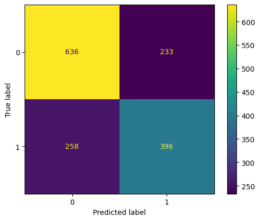

```python
rf_classifier = RandomForestClassifier().fit(X_train_rf, y_train)
y_pred_cv = rf_classifier.predict(X_cv_rf)
rf_metrics = calc_model_metrics(y_cv, y_pred_cv)
display_model_metrics('Random Forest Classifier', **rf_metrics)
```